# Sampling Distributions

Amey Joshi

16/11/2019

## The idea

If we draw $n$ samples from a population and compute the mean for each one of them we find that the means are not identical. The distribution of sample means is called the sampling distribution of means. We can extend this idea to any statistic. We demonstrate how to study sampling distribution of means and variances of water level of Lake Huron, one of the five great lakes in the north America.

The data set of water level of Lake Huron is available on every R installation.

## Visual examination of the data

The water level has a relatively narrow range about the mean.

```
## The highest level is 0.49% above the mean.
```

```
## The lowest level is 0.53% below the mean.
```

The highest and the lowest levels of the lake are not symmetrically placed about the mean. We expect the distribution of water level to by asymmetric about its mean. We check it by plotting the histogram with its empirical density.

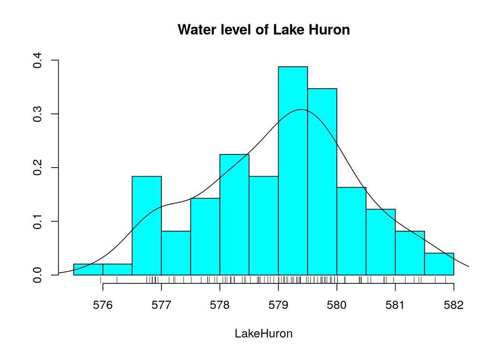

## Is the data normal?

In order to study the sampling distribution we first examine of the data is normal. We use the Shapiro-Wilk test whose null hypothesis is that the data is indeed normal.

```
## Data is normal.
## Shapiro-Wilk test has p-value 0.327 and significance level 0.05.
```

## Sampling distribution of means

If the population data is normally distributed then the standardized sample means are $t$-distributed with $\nu = n - 1$ degrees of freedom, $n$ being the sample size.

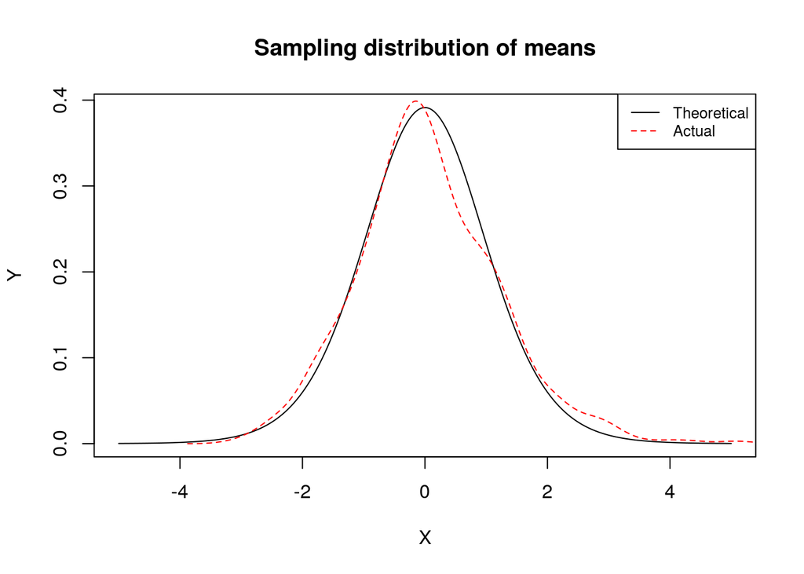

## Sampling distribution of variances

If the population data is normally distributed and the sample size if $n$ then we compute $(n - 1)s^2/\sigma^2$, where $s^2$ is the sample variance and $\sigma^2$ is the population variance. This quantity has as $\chi^2$-distribution with $n - 1$ degrees of freedom.

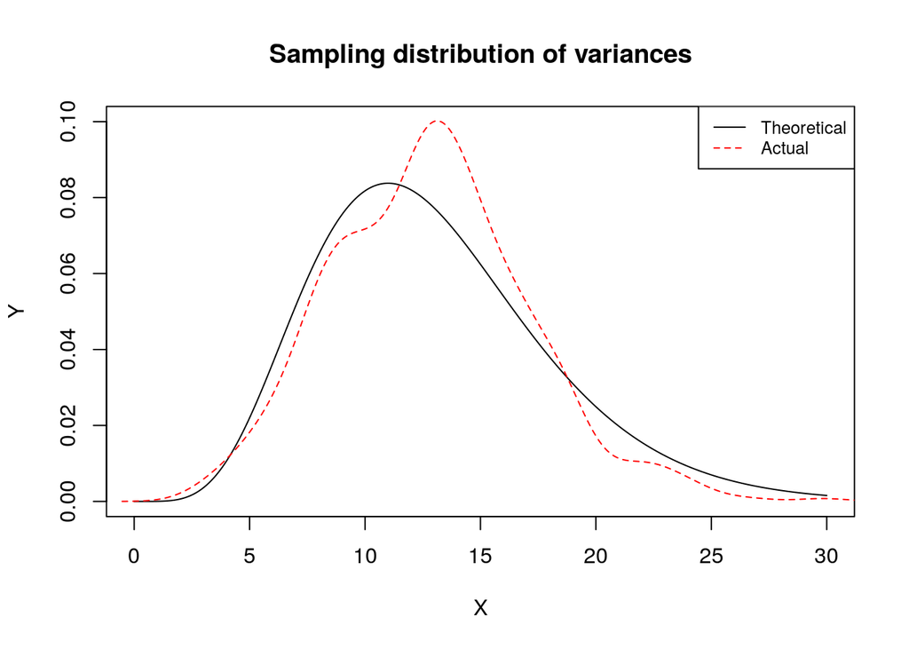